# Prognozowanie cukrzycy

Celem projektu jest zbudowanie i ocena modeli uczenia maszynowego, które będą w stanie skutecznie prognozować ryzyko wystąpienia cukrzycy na podstawie dostępnych danych medycznych i demograficznych pacjentów.

**Zbiór danych**

1. gender (object) - Płeć pacjenta.
   - Możliwe wartości: np. "Male", "Female".
   - Zmienna Kategoryczna
2. age (float64) - Wiek pacjenta wyrażony w latach.
3. hypertension (int64) Czy pacjent cierpi na nadciśnienie tętnicze.
   - Możliwe wartości: 0 – brak nadciśnienia, 1 – nadciśnienie występuje
4. heart_disease (int64) - Czy pacjent cierpi na chorobę serca.
   - Możliwe wartości: 0 – brak choroby serca, 1 – choroba serca występuje smoking_history (object)
5. Historia palenia papierosów przez pacjenta.
   - Możliwe wartości: np. "never", "former", "current", "No Info".
   - bmi (float64)
6. Wskaźnik masy ciała (Body Mass Index - BMI).
7. HbA1c_level (float64) - Średni poziom hemoglobiny glikowanej (HbA1c) we krwi.
8. blood_glucose_level (int64) - Poziom glukozy we krwi pacjenta.
9. diabetes (int64) - Zmienna docelowa. Czy pacjent cierpi na cukrzycę.
   - Możliwe wartości: 0 – brak cukrzycy, 1 – cukrzyca występuje

## 1. Import i sprawdzenia danych wejściowych

```python
import pandas as pd

df = pd.read_csv('diabetes_prediction_dataset.csv')

# Sprawdzenie danych wejściowych
df.info()
df.head()
```

```
<class 'pandas.core.frame.DataFrame'>
RangeIndex: 100000 entries, 0 to 99999
Data columns (total 9 columns):
 #   Column               Non-Null Count   Dtype
---  ------               --------------   -----
 0   gender               100000 non-null  object
 1   age                  100000 non-null  float64
 2   hypertension         100000 non-null  int64
 3   heart_disease        100000 non-null  int64
 4   smoking_history      100000 non-null  object
 5   bmi                  100000 non-null  float64
 6   HbA1c_level          100000 non-null  float64
 7   blood_glucose_level  100000 non-null  int64
 8   diabetes             100000 non-null  int64
dtypes: float64(3), int64(4), object(2)
memory usage: 6.9+ MB
```

|  | gender | age | hypertension | heart_disease | smoking_history | bmi | HbA1c_level | blood_glucose_level | diabetes |
| --- | --- | --- | --- | --- | --- | --- | --- | --- | --- |
| 0 | Female | 80.0 | 0 | 1 | never | 25.19 | 6.6 | 140 | 0 |
| 1 | Female | 54.0 | 0 | 0 | No Info | 27.32 | 6.6 | 80 | 0 |
| 2 | Male | 28.0 | 0 | 0 | never | 27.32 | 5.7 | 158 | 0 |
| 3 | Female | 36.0 | 0 | 0 | current | 23.45 | 5.0 | 155 | 0 |
| 4 | Male | 76.0 | 1 | 1 | current | 20.14 | 4.8 | 155 | 0 |

## 2. Eksploracyjna Analiza Danych (EDA)

```
- Analiza rozkładu zmiennej docelowej ("diabetes")
- Rozkład zmiennych kategorycznych ('gender', 'smoking_history')
- Analiza statystyczna zmiennych numerycznych ('age', 'bmi', 'HbA1c_level', 'blood_glucose_level').
- Macierz korelacji
```

```python
# Podział zmiennych na typy
categorical_columns = ['gender', 'smoking_history']
numerical_columns = ['age', 'bmi', 'HbA1c_level', 'blood_glucose_level']
binary_columns = ['hypertension', 'heart_disease', 'diabetes']

print("Zmienne kategoryczne:", categorical_columns)
print("Zmienne numeryczne:", numerical_columns)
print("Zmienne binarne:", binary_columns)

# Tworzenie podzbioru danych numerycznych
df_numeric = df[numerical_columns + binary_columns]
print(df_numeric.head())
```

```
Zmienne kategoryczne: ['gender', 'smoking_history']
Zmienne numeryczne: ['age', 'bmi', 'HbA1c_level', 'blood_glucose_level']
Zmienne binarne: ['hypertension', 'heart_disease', 'diabetes']
    age    bmi  HbA1c_level  blood_glucose_level  hypertension  heart_disease  \
0  80.0  25.19          6.6                  140             0              1
1  54.0  27.32          6.6                   80             0              0
2  28.0  27.32          5.7                  158             0              0
3  36.0  23.45          5.0                  155             0              0
4  76.0  20.14          4.8                  155             1              1

   diabetes
0         0
1         0
2         0
3         0
4         0
```

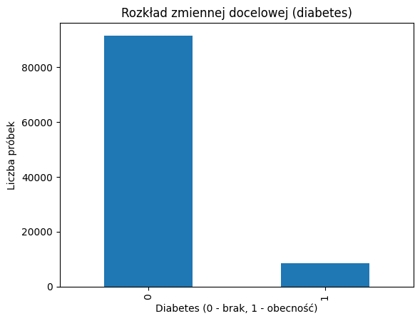

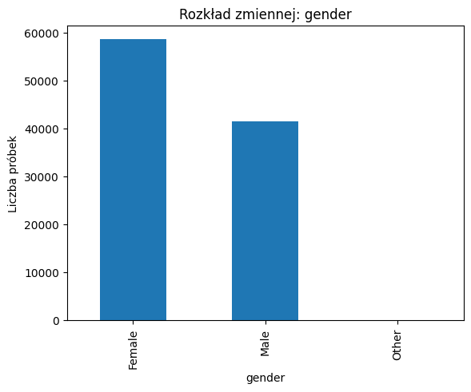

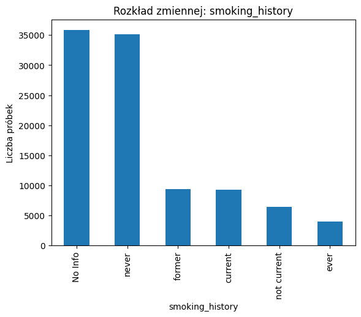

```
                 age            bmi    HbA1c_level  blood_glucose_level
count  100000.000000  100000.000000  100000.000000        100000.000000
mean       41.885856      27.320767       5.527507           138.058060
std        22.516840       6.636783       1.070672            40.708136
min         0.080000      10.010000       3.500000            80.000000
25%        24.000000      23.630000       4.800000           100.000000
50%        43.000000      27.320000       5.800000           140.000000
75%        60.000000      29.580000       6.200000           159.000000
max        80.000000      95.690000       9.000000           300.000000
```

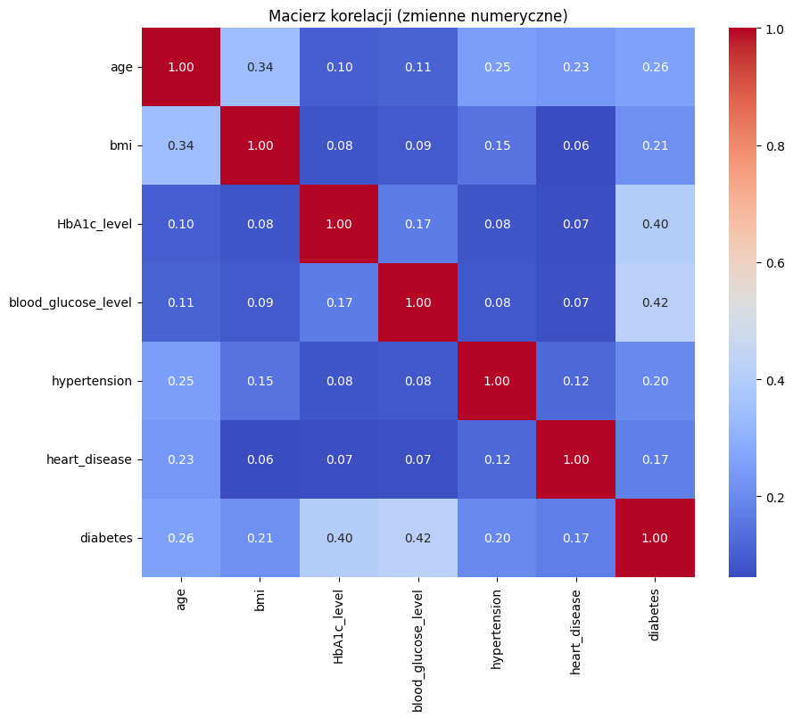

```python
import matplotlib.pyplot as plt
import seaborn as sns

# Rozkład zmiennej docelowej
df['diabetes'].value_counts().plot(kind='bar', title='Rozkład zmiennej docelowej (diabetes)')
plt.xlabel('Diabetes (0 - brak, 1 - obecność)')
plt.ylabel('Liczba próbek')
plt.show()


# Wizualizacja rozkładów zmiennych kategorycznych
for col in categorical_columns:
    df[col].value_counts().plot(kind='bar', title=f'Rozkład zmiennej: {col}')
    plt.xlabel(col)
    plt.ylabel('Liczba próbek')
    plt.show()


# Statystyki opisowe dla zmiennych numerycznych
print(df[numerical_columns].describe())


# Macierz Korelacji między zmiennymi
plt.figure(figsize=(10, 8))
sns.heatmap(df_numeric.corr(), annot=True, cmap='coolwarm', fmt='.2f')
plt.title('Macierz korelacji (zmienne numeryczne)')
plt.show()
```

### Wnioski z Eksploracyjnej Analizy Danych (EDA)

1. **Rozkład zmiennej docelowej:** Dane są niezbalansowane – zdecydowana większość próbek to przypadki bez cukrzycy.
2. **Zmienne kategoryczne:** Zmienna `gender` oraz `smoking_history` mają różny rozkład.
3. **Zmienne numeryczne:** Wiek, BMI oraz poziom glukozy wykazują zróżnicowanie w kontekście obecności cukrzycy.
4. **Korelacja:** Najsilniejszą korelację ze zmienną docelową wykazuje poziom glukozy oraz HbA1c.

## 3. Przygotowanie danych

### 3.1 Usunięcie brakujących wartości. (o ile istnieją)

```
- Zbiór faktycznie nie posiada brakujących wartości
```

```python
df = df.dropna()
print(df.isnull().sum())
```

```
gender                 0
age                    0
hypertension           0
heart_disease          0
smoking_history        0
bmi                    0
HbA1c_level            0
blood_glucose_level    0
diabetes               0
dtype: int64
```

### 3.2 Usuniecie wartości odstających (metoda IQR)

```
- Różnica między trzecim, a pierwszym kwantylem.
- Wartości mniejsze niż dolna granica i większe niż górna granica uznajemy za wartości odstające.
    Gdzie:
        - Dolna granica to Kwantyl_1 - 1.5(Kwantyl_3 - Kwantyl_1)
        - Górna granica to Kwantyl_3 + 1.5(Kwantyl_3 - Kwantyl_1)
```

```python
for col in numerical_columns:
    Q1 = df[col].quantile(0.25)
    Q3 = df[col].quantile(0.75)
    IQR = Q3 - Q1
    lower_bound = Q1 - 1.5 * IQR
    upper_bound = Q3 + 1.5 * IQR
    df = df[(df[col] >= lower_bound) & (df[col] <= upper_bound)]
```

### 3.3 Kodowanie zmiennych kategorycznych

```
- Kodujemy zmienne kategoryczne, aby otrzymać numeryczne, an których możemy pracować.
- Stosujemy One-Hot encoding ze względu na małą liczbe kategorii (sprawdza się dobrze dla takich przypadków)
```

```python
df = pd.get_dummies(df, columns=['gender', 'smoking_history'], drop_first=True)
print(df.head())
```

```
    age  hypertension  heart_disease    bmi  HbA1c_level  blood_glucose_level  \
0  80.0             0              1  25.19          6.6                  140
1  54.0             0              0  27.32          6.6                   80
2  28.0             0              0  27.32          5.7                  158
3  36.0             0              0  23.45          5.0                  155
4  76.0             1              1  20.14          4.8                  155

   diabetes  gender_Male  gender_Other  smoking_history_current  \
0         0        False         False                    False
1         0        False         False                    False
2         0         True         False                    False
3         0        False         False                     True
4         0         True         False                     True

   smoking_history_ever  smoking_history_former  smoking_history_never  \
0                 False                   False                   True
1                 False                   False                  False
2                 False                   False                   True
3                 False                   False                  False
4                 False                   False                  False

   smoking_history_not current
0                        False
1                        False
2                        False
3                        False
4                        False
```

### 3.4 Normalizacja i Standaryzacja danych

```python
from sklearn.preprocessing import StandardScaler

scaler = StandardScaler()
df[numerical_columns] = scaler.fit_transform(df[numerical_columns])

print(df.head())
```

```
        age  hypertension  heart_disease       bmi  HbA1c_level  \
0  1.710746             0              1 -0.231137     1.149580
1  0.558196             0              0  0.205441     1.149580
2 -0.594353             0              0  0.205441     0.244933
3 -0.239722             0              0 -0.587779    -0.458682
4  1.533431             1              1 -1.266217    -0.659715

   blood_glucose_level  diabetes  gender_Male  gender_Other  \
0             0.154198         0        False         False
1            -1.550459         0        False         False
2             0.665596         0         True         False
3             0.580363         0        False         False
4             0.580363         0         True         False

   smoking_history_current  smoking_history_ever  smoking_history_former  \
0                    False                 False                   False
1                    False                 False                   False
2                    False                 False                   False
3                     True                 False                   False
4                     True                 False                   False

   smoking_history_never  smoking_history_not current
0                   True                        False
1                  False                        False
2                   True                        False
3                  False                        False
4                  False                        False
```

### 3.5 Sprawdzenie zbalansowania zbioru danych po przygotowaniu danych

```
- Rozkład zmiennej docelowej
```

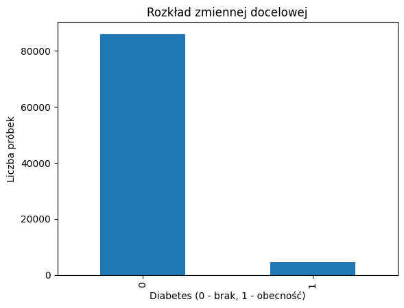

```python
df['diabetes'].value_counts().plot(kind='bar', title='Rozkład zmiennej docelowej')
plt.xlabel('Diabetes (0 - brak, 1 - obecność)')
plt.ylabel('Liczba próbek')
plt.show()
```

Dane są gotowe do podziału na zbiór uczący i testowy.

### 4. Podział zbioru na Uczący i Testowy

```
- Train set - Uzywany do trenowania modelu (zawiera 80% zmiennych)
- Test set - Używany do sprawdzenia modelu (zawiera 20% zmiennych)
```

```python
from sklearn.model_selection import train_test_split

# objaśniające (X) zmienna docelowa (Y)
X = df.drop('diabetes', axis=1)
y = df['diabetes']

X_train, X_test, y_train, y_test = train_test_split(
    X, y,
    test_size=0.2,
    random_state=42,
    stratify=y
)
print("X_train:", X_train.shape)
print("X_test:", X_test.shape)
print("y_train:", y_train.shape)
print("y_test:", y_test.shape)
```

```
X_train: (72309, 13)
X_test: (18078, 13)
y_train: (72309,)
y_test: (18078,)
```

## 5. Zastosowanie metod uczenia maszynowego

```
- Drzewo decyzyjne
- SVM
- Regresja logistyczna

Wyniki oceniane na bazie metryk: Accuracy (Dokładność), Precision (Precyzja), Recall (Czułość) i F1 Score.
F1 Score to średnia harmoniczna między Precision a Recall.
Jest to dodatkowa metryka do oceny jednocześnie jakości wykrywania pozytywnych wyników i minimalizacji fałszywych.
```

### 5.1 Drzewo decyzyjne

```python
# Importowanie klasy DecisionTreeClassifier oraz metryk oceny
from sklearn.tree import DecisionTreeClassifier
from sklearn.metrics import accuracy_score, precision_score, recall_score, f1_score, confusion_matrix

# Tworzenie i trenowanie modelu drzewa decyzyjnego
dt_model = DecisionTreeClassifier(random_state=42)
dt_model.fit(X_train, y_train)

# Prognozowanie
y_pred_dt = dt_model.predict(X_test)

# Ocena modelu
print("📊 Drzewo Decyzyjne")
print("Accuracy:", accuracy_score(y_test, y_pred_dt))
print("Precision:", precision_score(y_test, y_pred_dt))
print("Recall:", recall_score(y_test, y_pred_dt))
print("F1 Score:", f1_score(y_test, y_pred_dt))
print("\nConfusion Matrix:")
print(confusion_matrix(y_test, y_pred_dt))
```

```
📊 Drzewo Decyzyjne
Accuracy: 0.9548069476712026
Precision: 0.5443722943722944
Recall: 0.5595105672969967
F1 Score: 0.5518376302797586

Confusion Matrix:
[[16758   421]
 [  396   503]]
```

**Dokładność** 95.48% -> bardzo wysoka, model dobrze klasyfikuje obserwacje. **Precyzja** 54.43% -> Model często przewiduje fałszywie pozytywne przypadki. **Czułość** 55.95% -> Sugeruje, że model nie idetyfikuje dużej ilości pozytywnych przypadków. **F1 Score** 55.18% -> Wskazuję na potrzebę poprawy balansu między FP and FN (F1 to średnia harmoniczna między Precision i Recall)

### 5.2 SVM

```python
from sklearn.svm import SVC
from sklearn.metrics import accuracy_score, precision_score, recall_score, f1_score, confusion_matrix

svm_model = SVC(kernel='linear', random_state=42)
svm_model.fit(X_train, y_train)

y_pred_svm = svm_model.predict(X_test)

print("\n📊 Maszyna Wektorów Nośnych (SVM)")
print("Accuracy:", accuracy_score(y_test, y_pred_svm))
print("Precision:", precision_score(y_test, y_pred_svm))
print("Recall:", recall_score(y_test, y_pred_svm))
print("F1 Score:", f1_score(y_test, y_pred_svm))
print("\nConfusion Matrix:")
print(confusion_matrix(y_test, y_pred_svm))
```

```
📊 Maszyna Wektorów Nośnych (SVM)
Accuracy: 0.9624405354574621
Precision: 0.9583333333333334
Recall: 0.25583982202447164
F1 Score: 0.4038630377524144

Confusion Matrix:
[[17169    10]
 [  669   230]]
```

**Dokładność** 96.24% -> Bardzo wysoka, model skutecznie klasyfikuje obserwacje. **Precyzja** 95.83% -> Model rzadko generuje fałszywie pozytywne przypadki, co oznacza wysoką dokładność w przewidywaniu pozytywnych klas. **Czułość** 25.59% -> Sugeruje, że model ma trudności z identyfikacją dużej liczby pozytywnych przypadków, co prowadzi do wysokiej liczby fałszywie negatywnych wyników. **F1 Score** 40.38% -> Wskazuje na nierównowagę między FP (False Positives) i FN (False Negatives). Model dobrze przewiduje klasy negatywne, ale ma problemy z klasą pozytywną.

### 5.3 Regresja logistyczna

```python
from sklearn.linear_model import LogisticRegression
from sklearn.metrics import accuracy_score, precision_score, recall_score, f1_score, confusion_matrix

lr_model = LogisticRegression(random_state=42)
lr_model.fit(X_train, y_train)

y_pred_lr = lr_model.predict(X_test)

print("\n📊 Regresja Logistyczna")
print("Accuracy:", accuracy_score(y_test, y_pred_lr))
print("Precision:", precision_score(y_test, y_pred_lr))
print("Recall:", recall_score(y_test, y_pred_lr))
print("F1 Score:", f1_score(y_test, y_pred_lr))
print("\nConfusion Matrix:")
print(confusion_matrix(y_test, y_pred_lr))
```

```
📊 Regresja Logistyczna
Accuracy: 0.964487222037836
Precision: 0.8037825059101655
Recall: 0.3781979977753059
F1 Score: 0.5143721633888049

Confusion Matrix:
[[17096    83]
 [  559   340]]
```

## 6. Analiza uzyskanych wyników (analiza jakości klasyfikacji, porównanie wyników uzyskanych za pomocą różnych metod),

```
                 Model  Accuracy  Precision    Recall  F1 Score
0        Decision Tree  0.954807   0.544372  0.559511  0.551838
1                  SVM  0.962441   0.958333  0.255840  0.403863
2  Logistic Regression  0.964487   0.803783  0.378198  0.514372
```

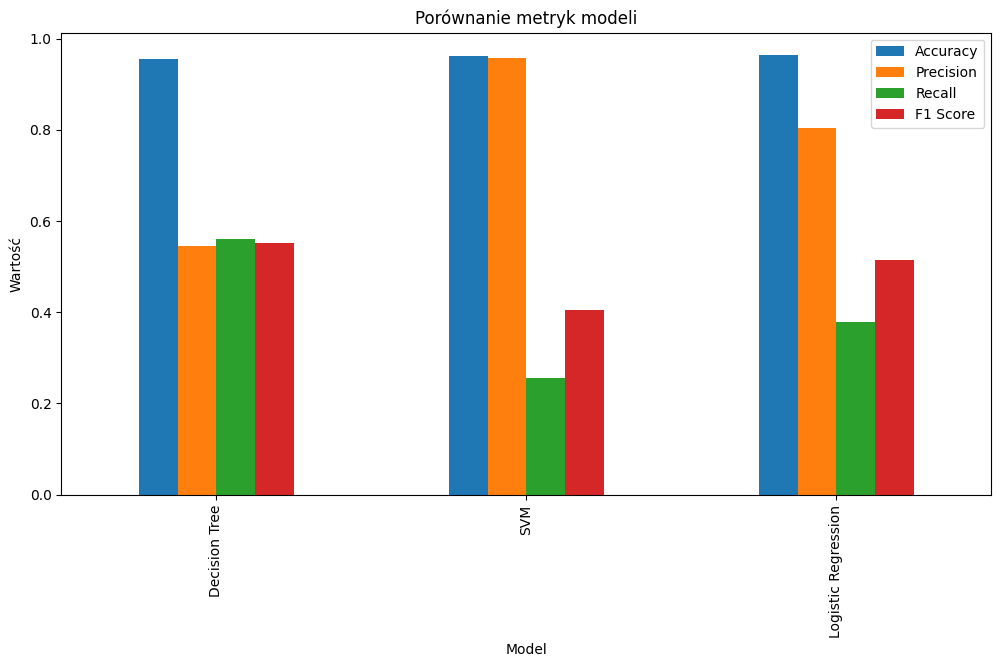

```python
import pandas as pd
import matplotlib.pyplot as plt

results = {
    "Model": ["Decision Tree", "SVM", "Logistic Regression"],
    "Accuracy": [accuracy_score(y_test, y_pred_dt), accuracy_score(y_test, y_pred_svm), accuracy_score(y_test, y_pred_lr)],
    "Precision": [precision_score(y_test, y_pred_dt), precision_score(y_test, y_pred_svm), precision_score(y_test, y_pred_lr)],
    "Recall": [recall_score(y_test, y_pred_dt), recall_score(y_test, y_pred_svm), recall_score(y_test, y_pred_lr)],
    "F1 Score": [f1_score(y_test, y_pred_dt), f1_score(y_test, y_pred_svm), f1_score(y_test, y_pred_lr)]
}
results_df = pd.DataFrame(results)
print(results_df)

results_df.set_index('Model').plot(kind='bar', figsize=(12, 6), title='Porównanie metryk modeli')
plt.ylabel('Wartość')
plt.show()
```

### Porównanie Metryk Klasyfikacji

- **Accuracy:** Proporcja poprawnie sklasyfikowanych obserwacji.
- **Precision:** Dokładność przewidywań pozytywnej klasy.
- **Recall:** Zdolność do wykrycia wszystkich pozytywnych przypadków.
- **F1 Score:** Średnia harmoniczna precyzji i czułości (Recall).

**Dokładność (Accuracy)**

**Wniosek:** Wszystkie modele osiągnęły wysoką dokładność, co sugeruje, że dobrze klasyfikują większość danych.

**Precyzja (Precision)**

- **SVM (95.83%)** osiągnął najwyższą precyzję, co oznacza niewielką liczbę fałszywie pozytywnych przypadków.
- **Regresja Logistyczna (80.37%)** również ma przyzwoitą precyzję.
- **Drzewo Decyzyjne (54.43%)** osiągnęło najniższą wartość, co sugeruje większą liczbę fałszywych alarmów.

**Wniosek:** SVM dominuje pod względem precyzji, minimalizując fałszywie pozytywne klasyfikacje.

**Czułość (Recall)**

- **Drzewo Decyzyjne (55.95%)** uzyskało najlepszy wynik pod względem czułości, co oznacza, że lepiej identyfikuje pozytywne przypadki.
- **Regresja Logistyczna (37.81%)** osiągnęła umiarkowaną czułość.
- **SVM (25.58%)** wypadł najgorzej, co oznacza, że nie wykrywa wielu pozytywnych przypadków.

**Wniosek:** Drzewo Decyzyjne jest najlepsze w wykrywaniu przypadków pozytywnych, podczas gdy SVM ma z tym wyraźny problem.

**F1 Score**

- **Drzewo Decyzyjne (55.18%)** osiągnęło najwyższy wynik F1, co sugeruje dobrą równowagę między precyzją a czułością.
- **Regresja Logistyczna (51.43%)** uzyskała drugi najlepszy wynik F1.
- **SVM (40.38%)** ma najniższą wartość F1, co wynika z niskiej czułości.

**Wniosek:** Drzewo Decyzyjne utrzymuje najlepszą równowagę między Precision a Recall.

- **Najlepszy model pod względem Accuracy:** **Regresja Logistyczna**
- **Najlepszy model pod względem Precision:** **SVM**
- **Najlepszy model pod względem Recall:** **Drzewo Decyzyjne**
- **Najlepszy balans Precision i Recall (F1 Score):** **Drzewo Decyzyjne**

Dla tego konkretnego przypadku zdecydowanie bardziej zależy nam na klasyfikacji na tak, nawet jeżeli nie. Niż klasyfikacji na nie, gdy jest możliwe tak. Wynika to z faktu iż mówimy o identyfikacji poważnej choroby.

W związku z tym najlepszym z trzech jest Drzewo Decyzjne (zdecydowanie najwyższy Recall), brak odbiegającgo wyniku w Dokładności. Precyzja w tym wypadku (wykrycie choroby) jest mniej istotna.

### 6.2 Analiza Macierzy Błędów

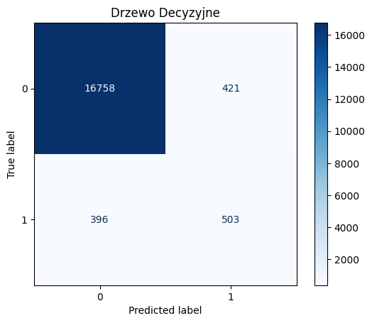

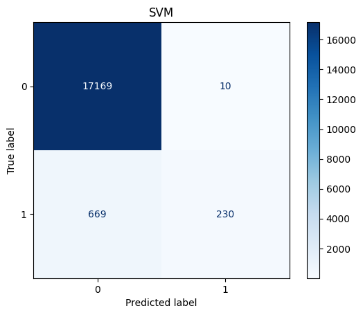

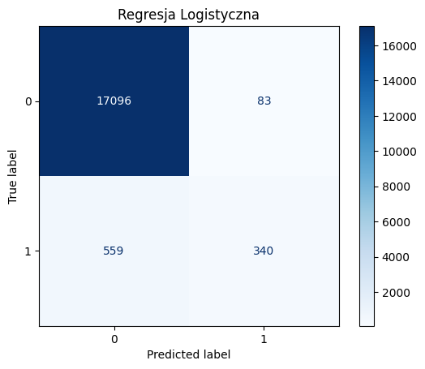

```python
from sklearn.metrics import ConfusionMatrixDisplay

def plot_confusion_matrix(model, y_true, y_pred, title):
    disp = ConfusionMatrixDisplay.from_predictions(y_true, y_pred, cmap='Blues')
    plt.title(title)
    plt.show()

plot_confusion_matrix(dt_model, y_test, y_pred_dt, 'Drzewo Decyzyjne')
plot_confusion_matrix(svm_model, y_test, y_pred_svm, 'SVM')
plot_confusion_matrix(lr_model, y_test, y_pred_lr, 'Regresja Logistyczna')
```

#### Macierz Błędów

- **True Positives (TP):** Poprawnie przewidziane przypadki pozytywne.
- **True Negatives (TN):** Poprawnie przewidziane przypadki negatywne.
- **False Positives (FP):** Błędnie przewidziane przypadki pozytywne.
- **False Negatives (FN):** Błędnie przewidziane przypadki negatywne.

**Wnioski ogólne:**

1. **True Negatives:** SVM ma najwyższą liczbę poprawnie sklasyfikowanych klas negatywnych (17,169).
2. **False Positives:** SVM ma najniższą liczbę fałszywie pozytywnych klasyfikacji (10).
3. **False Negatives:** Drzewo Decyzyjne ma najmniejszą liczbę błędnych klasyfikacji klasy pozytywnej (396).
4. **True Positives:** Drzewo Decyzyjne osiąga najlepsze wyniki w klasyfikacji klasy pozytywnej (503).

**Drzewo Decyzyjne:** Najlepiej równoważy klasyfikację obu klas, z akceptowalnymi wartościami FP i FN. **SVM:** Doskonale klasyfikuje klasę negatywną, ale praktycznie ignoruje klasę pozytywną. **Regresja Logistyczna:** Lepsza równowaga niż w SVM, ale wciąż ma problemy z wykrywaniem pozytywnych przypadków.

**Finalnie** W kontekście zbioru danych (wykrywanie cukrzycy) najlepszą opcją nadal jest **Drzewo Decyzyjne** z uwagi na najlepsze wyniki pozytywnej klasyfikacji. Idąc myślą, że dla tego konkretnego przypadku lepiej jest wykryć niż nie wykryć.

### 6.3 Krzywa ROC i AUC (Receiver Operating Characteristic)

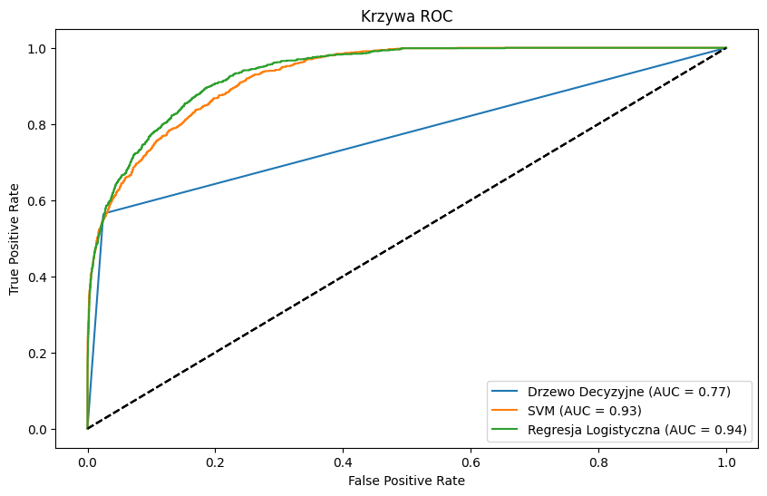

```python
from sklearn.metrics import roc_curve, auc

# Funkcja do wyświetlania krzywej ROC
def plot_roc_curve(model, X_test, y_test, label):
    y_probs = model.predict_proba(X_test)[:, 1] if hasattr(model, "predict_proba") else model.decision_function(X_test)
    fpr, tpr, thresholds = roc_curve(y_test, y_probs)
    roc_auc = auc(fpr, tpr)

    plt.plot(fpr, tpr, label=f'{label} (AUC = {roc_auc:.2f})')
    plt.plot([0, 1], [0, 1], 'k--')
    plt.xlabel('False Positive Rate')
    plt.ylabel('True Positive Rate')
    plt.title('Krzywa ROC')
    plt.legend(loc='lower right')

# Wyświetlenie krzywych ROC dla modeli
plt.figure(figsize=(10, 6))
plot_roc_curve(dt_model, X_test, y_test, 'Drzewo Decyzyjne')
plot_roc_curve(svm_model, X_test, y_test, 'SVM')
plot_roc_curve(lr_model, X_test, y_test, 'Regresja Logistyczna')
plt.show()
```

#### 📊 Krzywa ROC/AUC

- Krzywa przedstawia zależność między czułością (Recall) a współczynnikiem fałszywie pozytywnych wyników.
- Im większa wartość AUC, tym lepszy model.

**Interpretacja wykresu:**

1. **Regresja Logistyczna** ma najbardziej optymalną krzywą ROC i najwyższą wartość AUC, co sugeruje najlepsze wyróżnianie klas.
2. **SVM** osiąga bardzo zbliżony wynik do regresji logistycznej i jest również skutecznym modelem.
3. **Drzewo Decyzyjne** ma najniższy wynik AUC i najbardziej płaską krzywą, co wskazuje na problemy z wyróżnianiem klas w różnych progach decyzyjnych.

Najlepszy model (wg AUC): Regresja Logistyczna (0.94) Najbliższy konkurent: SVM (0.93) Najgorszy wynik: Drzewo Decyzyjne (0.77)

## 7. Analiza interpretowalności wybranego modelu

### 7.1 Wybór Najlepszego Modelu

```
- Regresja logistyczna
```

### 7.2 Wykresy Częściowej Zależności (PDP - Partial Dependence Plots)

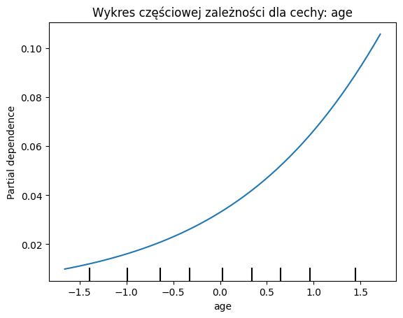

```python
from sklearn.inspection import partial_dependence, PartialDependenceDisplay

# Wykres częściowej zależności dla wybranej zmiennej
feature = 'age'  # Możesz zmienić na inną zmienną

PartialDependenceDisplay.from_estimator(
    lr_model, X_test, [feature],
    kind='average', grid_resolution=50
)
plt.title(f'Wykres częściowej zależności dla cechy: {feature}')
plt.show()
```

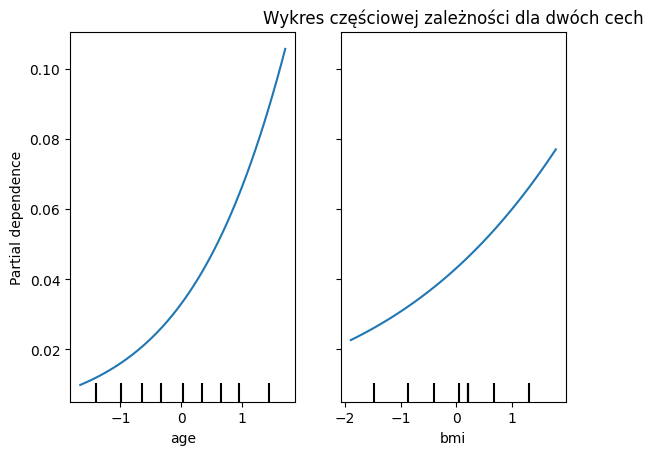

```python
# Wykres PDP dla dwóch zmiennych
features = ['age', 'bmi']
PartialDependenceDisplay.from_estimator(
    lr_model, X_test, features,
    kind='average', grid_resolution=50
)
plt.title('Wykres częściowej zależności dla dwóch cech')
plt.show()
```

**Wzrost wartości cechy (age):**

- Wraz ze wzrostem wieku rośnie prawdopodobieństwo wystąpienia cukrzycy.
- Zależność ma charakter nieliniowy, z coraz większym przyrostem ryzyka dla wyższych wartości wieku.

**Wskaźnik masy ciała (bmi)**

- Wzrost BMI zwiększa prawdopodobieństwo wystąpienia cukrzycy.
- Zależność jest nieliniowa.

**Kombinacja (age) i (bmi):**

### 7.3 LIME (Local Interpretable Model-Agnostic Explanations)

```python
import lime
import lime.lime_tabular

explainer = lime.lime_tabular.LimeTabularExplainer(
    training_data=X_train.values,
    feature_names=X_train.columns.tolist(),
    class_names=['No Diabetes', 'Diabetes'],
    mode='classification'
)
i = 0
exp = explainer.explain_instance(X_test.iloc[i].values, lr_model.predict_proba)
exp.show_in_notebook()
```

[output not shown]

### 7.4 Profil Ceteris Peribus

[output not shown]

[figure not shown]

[figure not shown]

```python
import dalex as dx
import matplotlib.pyplot as plt

explainer = dx.Explainer(lr_model, X_test, y_test)
instance = X_test.iloc[0]
cp_profile = explainer.predict_profile(instance)

# AGE
cp_profile.plot(variables=["age"])
plt.title("Profil Ceteris Paribus dla cechy: age")
plt.show()

# HbA1c_level
cp_profile.plot(variables=["HbA1c_level"])
plt.title("Profil Ceteris Paribus dla cechy: HbA1c_level")
plt.show()
```

## 8. Podsumowanie CAŁKOWICIE DO POPRAWY!!

Celem projektu było zbudowanie, ocena i interpretacja modeli klasyfikacyjnych do przewidywania ryzyka wystąpienia cukrzycy.

Zidentyfikowano kluczowe zmienne wpływające na wystąpienie cukrzycy, takie jak HbA1c_level, blood_glucose_level, age oraz bmi.

W projekcie zastosowano trzy różne algorytmy:

Drzewo Decyzyjne:

- Accuracy: 95.48%
- Precision: 54.43%
- Recall: 55.95%
- F1 Score: 55.18%

SVM:

- Accuracy: 96.24%
- Precision: 95.83%
- Recall: 25.58%
- F1 Score: 40.38%

Regresja Logistyczna:

- Accuracy: 96.44%
- Precision: 80.37%
- Recall: 37.82%
- F1 Score: 51.44%

**Wnioski:**

- Monitorowanie HbA1c: Regularne badania poziomu HbA1c powinny być priorytetem w diagnostyce cukrzycy.
- Profilaktyka dla grup ryzyka: Szczególną uwagę należy zwrócić na starszych pacjentów oraz osoby z wysokim BMI.